# Coursework Report

*N* removed NAs: 6

*N* removed <18: 30

**Correct typo age:** 19

*N* total clean: 132

| Group | *N* | *M*<sub>age</sub> | % green |
| --- | --- | --- | --- |
| Control | 66 | 20.7 | 46.0 |
| Experim | 66 | 20.6 | 37.4 |

| Gender | *N* | *M*<sub>age</sub> | % green |
| --- | --- | --- | --- |
| Female | 68 | 20.8 | 39.7 |
| Male | 38 | 20.4 | 47.4 |
| Other | 26 | 20.6 | 38.5 |

**Main analysis results**

**car:**  
χ<sup>2</sup>(1) = 0, *p* = 1.000

**cleaner:**  
χ<sup>2</sup>(1) = 5.36, *p* = .021

**dishwasher:**  
χ<sup>2</sup>(1) = 0.28, *p* = .597

[interactive chart not shown]

[figure not shown]

[interactive chart not shown]

# Coursework Report

Analysing Data, Spring 2020

# Methods

## Participants

Participant Demographics by Experimental Condition and Gender

[output not shown]

## Design

This study is a replication of Griskevicius and colleagues’ (2010) study. In their study Griskevicius et. al. (2010) reported that, when activated, status motives increased people’s choice for green product when an equally-priced luxury product was available possible reason for this being participants’ desires of behaving pro-socially. In this replication, the research question was whether or not the original study’s effect is reproducible. Here and in original paper there were two between-subject conditions: control and experimental. In both conditions, prior to making choices about products, participants read a short, about 700 words, story, which based on the condition either elicited status motives, such as desires for social status and prestige (Tybur, et al., 2009), or was a control story of similar length but not affecting status motives. After reading the story manipulating motives, participants were asked to pick between a luxurious and a green type of product for a dishwasher, a car and a soap. The products were presented in random order. The analysed dependant variable in this study is a factor variable – a choice between the type of products, green or luxurious, for all three products. Independent variables were the story conditions, high-status or control. For all products, both choices were equally priced and produced by the same company. However, luxurious items were often described as products with high level of performance, while green products focused on being environmentally-friendly and recourse-saving. The operationalised hypothesis for this study is that reading high-status story would result in some difference in product choice between green and luxurious products compared to choices made after reading the control story. This hypothesis will be tested using Chi-squared statistical test.

# Results

As seen in the bar graphs below, for all products, an eco-friendlier choice was not opted for more. In fact, the luxury options were more popular than greener options in high-status conditions for both the soap and the dishwasher, and when choosing a car, the luxury option was more popular in both control and high-status conditions.

Product Choice by Story Type for Soap

|  | Non-Green Luxury Product | Green Product |
| --- | --- | --- |
| Control Story | 33 | 33 |
| High-Status Story | 47 | 19 |

Product Choice by Story Type for Dishwasher

|  | Non-Green Luxury Product | Green Product |
| --- | --- | --- |
| Control Story | 36 | 30 |
| High-Status Story | 40 | 26 |

Product Choice by Story Type for Car

|  | Non-Green Luxury Product | Green Product |
| --- | --- | --- |
| Control Story | 37 | 28 |
| High-Status Story | 37 | 29 |

For soap, 71.21 percent of those who read the high-status chose the luxurious option, compared to 50 percent of those who opted for the same choice in control story condition *χ*<sup>2</sup>(1) = 5.36, *p* = 0.021, suggesting a significant relationship between a high-status story and product choice.

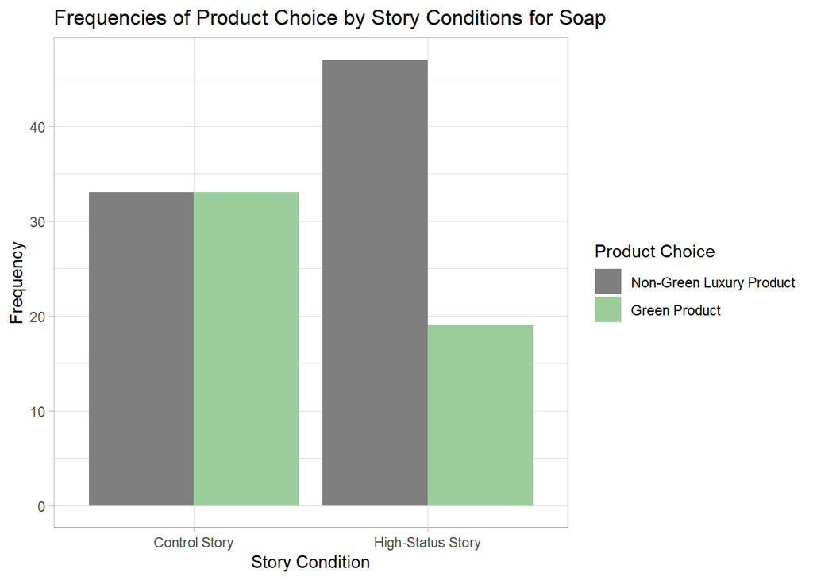

On the other hand, although with increase in percentage for luxurious dishwasher in high-status condition compared to control condition, 54.55 to 60.61, the Chi-Squared showed relationship between the story type and product choice but it was insignificant *χ*<sup>2</sup>(1) = 0.28, *p* = 0.6.

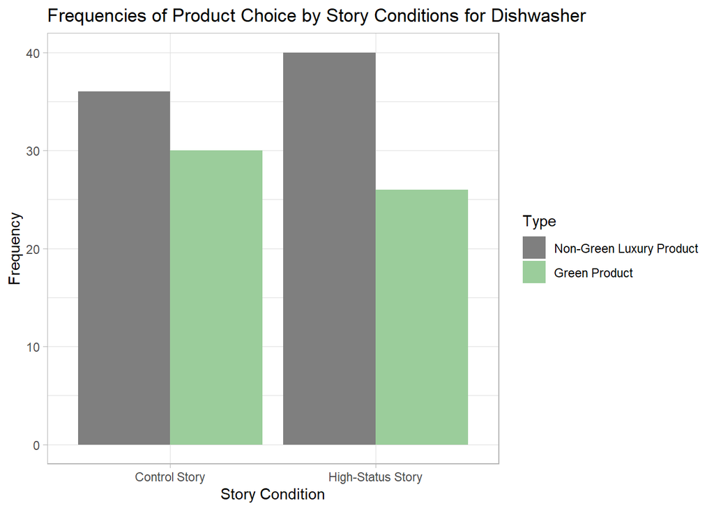

There was no significant relationship between experimental story and product choice when it came to choosing cars as there was only insignificant difference in percentages between both conditions and the luxurious car was chosen more often in both conditions - 56.06 in experimental and 56.92 in control conditions for a luxurious car; 43.94 and 43.08 for a green car *χ*<sup>2</sup>(1) = 0, *p* = 1.

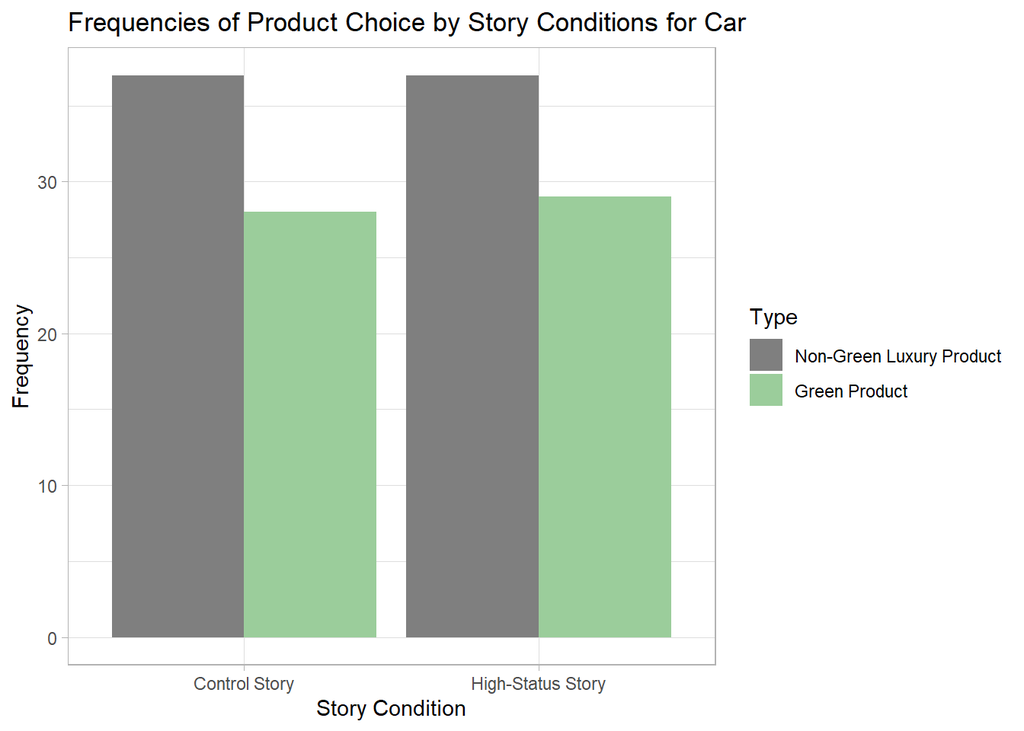

# Discussion

Overall, it appears as this study’s data disagrees with the original study, as we did not see an increase in selecting green products after participants read the status-activating story, but an increase in selecting luxurious products instead. This may suggest that the effect observed in Griskevicius and colleagues’ (2010) study is not reproducible. Several studies may explain why our study’s data differ from the original Griskevicius et al. (2010) study. For example, Sundie et al. (2011) found similarities in patterns of behaviour of males and peacocks in a way that males might choose more expensive products to charm potential mates. However, in our study we examined this effect in both male and female participants, so it may not fully explain why people of both genders chose the luxurious product over the green one. In addition, participants may have chosen the luxurious products because of their desires to maintain high perceived social status, we could interpret this as choosing a luxurious product would make one appear as someone who has a higher status, rather than if they would choose a non-luxurious green product. Anderson et al. (2015) showed that level of status affects psychological well-being, such as those with higher status having higher reported self-esteem and life satisfaction, compared to those with lower status which increased depression and anxiety, as well as physical health outcomes. In context of our study these could be interpreted as participants choosing the luxurious products because of the positive effects associated with it. Furthermore, Hartmann & Apaolaza-Ibáñez (2012) study’s results suggest that the self-expressive benefits of green brands, such as pro-social behaviour, do not affect purchase intention. They also add that such findings are consistent with Griskevicius et al. (2010) where it was found that status motives only influenced purchase intention only when goods are consumed in private, this goes along with our findings for soap and dishwasher products, however fails to explain why the non-green car was chosen more often in both conditions, if it is used publically. Generally, it appears as the existence of the relationship between high-status motives and increase in choice for green products may be unlikely, due to luxurious products having more positive effects for users’ psychological well-being and choice for greener options only when it can be used in public. This study is not exactly applicable to test the reasons why participants chose the specific type of product, as they were simply not recorded. An implication for future research, as well as balancing the amount of participants of each gender to rule out this variable, is to conduct an interview or ask participants to fill out a survey stating reasons for their product choices to be able to tell more objectively if their choices were made due to the high-status benefits or social acceptance.

# References

Anderson, C., Hildreth, J. A. D., & Howland, L. (2015).Is the desire for status a fundamental human motive? A review of the empirical literature *Psychological Bulletin, 141*(3), 574–601.

Griskevicius, V., Tybur, J. M., & Van den Bergh, B. (2010). Going green to be seen: Status, reputation, and conspicuous conservation. *Journal of Personality and Social Psychology, 98*(3), 392–404.

Hartmann, P., & Apaolaza-Ibáñez, V. (2012). Consumer attitude and purchase intention toward green energy brands: The roles of psychological benefits and environmental concern. *Journal of Business Research, 65*(9), 1254–1263.

Sundie, J. M., Kenrick, D. T., Griskevicius, V., Tybur, J. M., Vohs, K. D., & Beal, D. J. (2011). Peacocks, Porsches, and Thorstein Veblen: Conspicuous consumption as a sexual signaling system. *Journal of Personality and Social Psychology, 100*(4), 664–680.

Tybur, J. M., Lieberman, D., & Griskevicius, V. (2009). Microbes, mating, and morality: Individual differences in three functional domains of disgust. *Journal of Personality and Social Psychology, 97*(1), 103-122.